# Attrition

Muchigi

11/28/2019

```r
knitr::opts_chunk$set(echo = TRUE)
```

Imported Libraries

```r
#Bring in library's
library(ggplot2)
library(dplyr)
library(GGally)
library(mlbench)
library(class)
library(caret)
library(e1071)
library (MASS)
```

Bring in the data

```r
df <-read.csv('/Users/muchigi.kimari@mckesson.com/Google Drive/Doing_data_science/Doing/CaseStudy2_2_2_2/CaseStudy2-data.csv')
```

Dropped the column over18 because it has one level

```r
#this column had only one level so I dropped it
df <-subset(df,select = -c(Over18,EmployeeCount, StandardHours))
```

Below checks if we have any Nulls

```r
#No missing values in the data
sum(is.null(df))
```

```
## [1] 0
```

Will filer the data to Attrition because we want to see the role with the highest Attrition

```r
#No missing values in the data
Attrition<-df %>% filter(Attrition =='Yes')
```

Below shows which role has the highest Attrition

-Sales Excutive has the highest Attrition

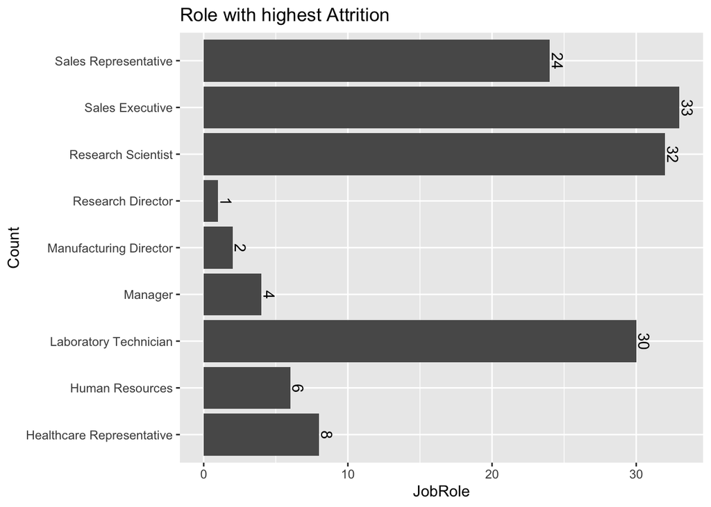

```r
# ran a bar graph plot
ggplot(Attrition) +
  aes(x = JobRole) +
  geom_bar() +
  geom_text(stat = 'count',aes(label =..count..),angle = 270, vjust = -0.2)+
  coord_flip()+ggtitle("Role with highest Attrition")+xlab("Count") + ylab("JobRole")
```

Below are features that i believe lead to Attrition

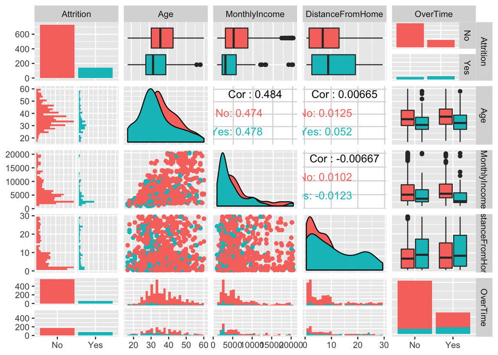

```r
df%>%dplyr::select(Attrition,Age,MonthlyIncome,DistanceFromHome,OverTime)%>%ggpairs(aes(color = Attrition))
```

Since we have the factors, lets dig a little deeper

You can see from the stacked histogram that younger employees have a higher rate of attrition

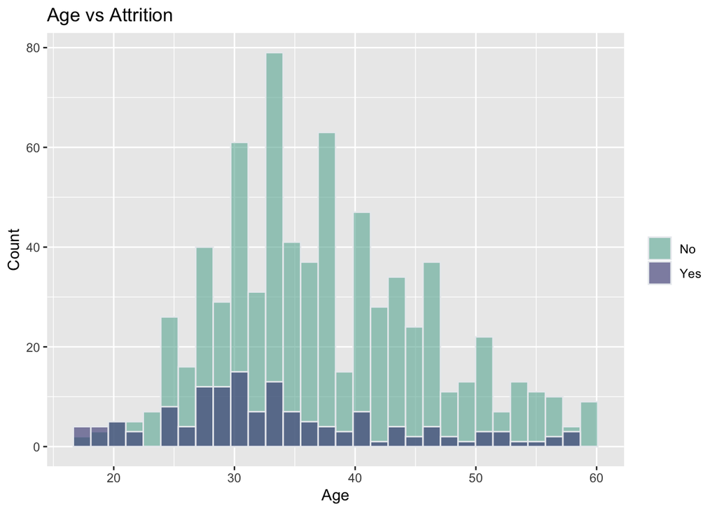

```r
df%>%ggplot( aes(x=Age, fill=Attrition)) +
    geom_histogram( color="#e9ecef", alpha=0.6, position ='identity')+scale_fill_manual(values=c("#69b3a2", "#404080")) +labs(fill="")+ggtitle("Age vs Attrition")+xlab("Age") + ylab("Count")
```

You can see from the stacked histogram below that employees with lower income have a higher rate of attrition

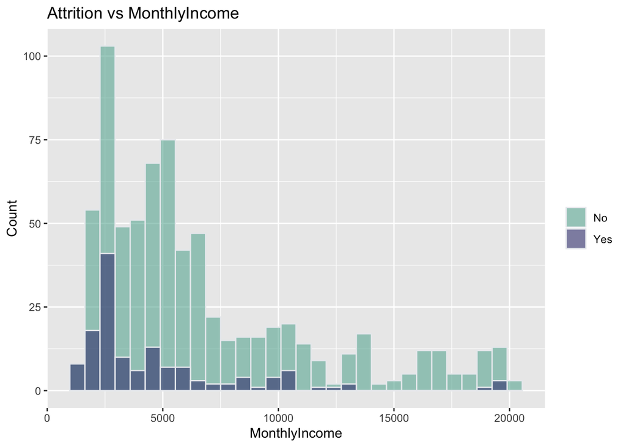

```r
df%>%ggplot( aes(x=MonthlyIncome, fill=Attrition)) +
    geom_histogram( color="#e9ecef", alpha=0.6, position ='identity')+scale_fill_manual(values=c("#69b3a2", "#404080")) +labs(fill="")+ggtitle("Attrition vs MonthlyIncome")+xlab("MonthlyIncome") + ylab("Count")
```

You can see from the box plot that the distribution for Attrition is high for employees that drive far

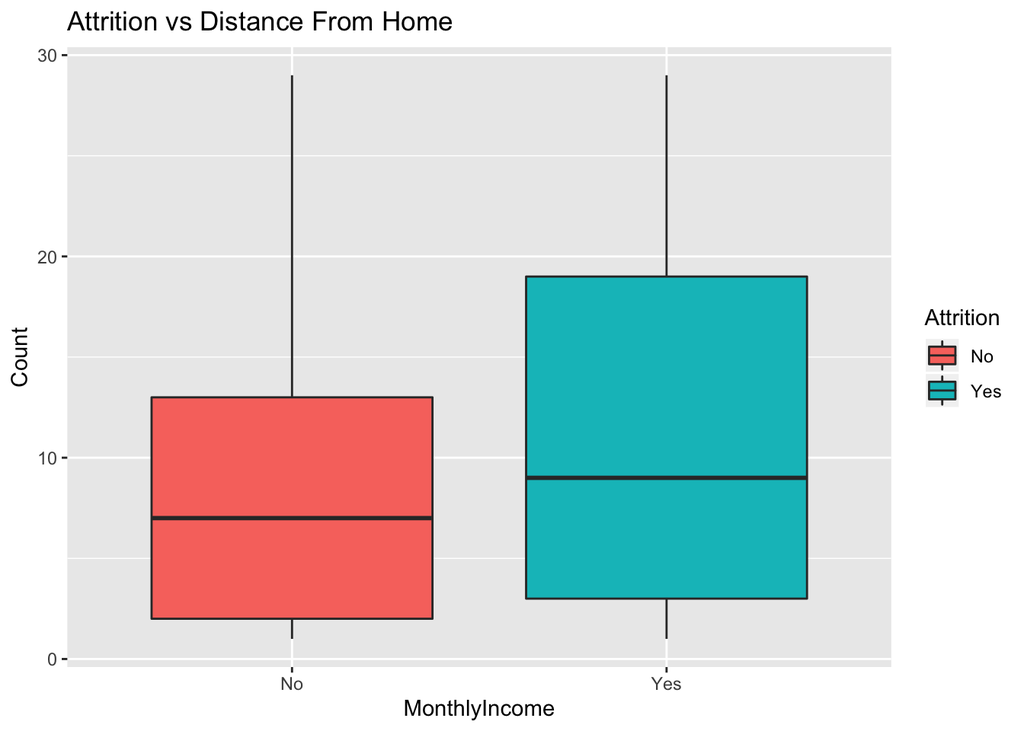

```r
df%>%ggplot( aes(x=Attrition, y=DistanceFromHome, fill=Attrition)) +geom_boxplot()+ggtitle("Attrition vs Distance From Home")+xlab("MonthlyIncome") + ylab("Count")
```

To get the right features for the Knn i ran the top features function for predicting Attrition

```r
set.seed(7)
# load the library
library(mlbench)
library(caret)


# prepare training scheme
control <- trainControl(method="repeatedcv", number=10, repeats=3)
# train the model
model <- train(Attrition~.,data=df, method="lvq", preProcess="scale", trControl=control)
# estimate variable importance
importance <- varImp(model, scale=FALSE)
# summarize importance
print(importance)
```

```
## ROC curve variable importance
##
##   only 20 most important variables shown (out of 32)
##
##                         Importance
## OverTime                    0.6679
## MonthlyIncome               0.6567
## TotalWorkingYears           0.6563
## YearsAtCompany              0.6470
## StockOptionLevel            0.6455
## MaritalStatus               0.6438
## JobLevel                    0.6406
## YearsInCurrentRole          0.6403
## YearsWithCurrManager        0.6291
## Age                         0.6265
## JobInvolvement              0.6159
## JobSatisfaction             0.5833
## JobRole                     0.5829
## Department                  0.5605
## DistanceFromHome            0.5586
## EnvironmentSatisfaction     0.5532
## WorkLifeBalance             0.5491
## TrainingTimesLastYear       0.5428
## Education                   0.5384
## ID                          0.5371
```

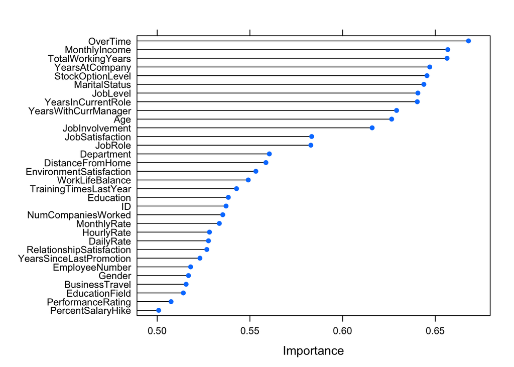

```r
# plot importance
plot(importance)
```

After running the feature importance, - I converted all my categrical data to Numeric

```r
#Selected the features based on the Feature importance function
modeldf<-df[,c(3,2,6,7,14,15,16,17,18,19,22,26,27,30,31,33)]

i <- sapply(modeldf,is.factor)

#converted the dataframe to numeric
modeldf[i] <- lapply(modeldf[i], as.numeric)
str(modeldf)
```

```
## 'data.frame':    870 obs. of  16 variables:
##  $ Attrition           : num  1 1 1 1 1 1 1 1 1 1 ...
##  $ Age                 : int  32 40 35 32 24 27 41 37 34 34 ...
##  $ Department          : num  3 2 2 3 2 2 2 3 3 2 ...
##  $ DistanceFromHome    : int  13 14 18 1 2 10 5 10 10 10 ...
##  $ JobInvolvement      : int  3 2 3 3 3 3 4 2 3 2 ...
##  $ JobLevel            : int  2 5 3 3 1 3 1 2 1 2 ...
##  $ JobRole             : num  8 6 5 8 7 5 7 8 9 1 ...
##  $ JobSatisfaction     : int  4 3 4 4 4 1 3 4 3 3 ...
##  $ MaritalStatus       : num  1 3 3 2 3 1 2 1 2 2 ...
##  $ MonthlyIncome       : int  4403 19626 9362 10422 3760 8793 2127 6694 2220 5063 ...
##  $ OverTime            : num  1 1 1 1 2 1 2 2 2 1 ...
##  $ StockOptionLevel    : int  1 0 0 2 0 2 0 3 1 1 ...
##  $ TotalWorkingYears   : int  8 21 10 14 6 9 7 8 1 8 ...
##  $ YearsAtCompany      : int  5 20 2 14 6 9 4 1 1 8 ...
##  $ YearsInCurrentRole  : int  2 7 2 10 3 7 2 0 1 2 ...
##  $ YearsWithCurrManager: int  3 9 2 7 3 7 3 0 0 7 ...
```

Ran the first Knn with K = 9

```r
splitPerc = .75
trainIndices = sample(1:dim(modeldf)[1],round(splitPerc * dim(modeldf)[1]))
train = modeldf[trainIndices,]
test = modeldf[-trainIndices,]

classification = knn(train[,2:16] ,test[,2:16],train$Attrition,prob = TRUE, k = 9)

table(classification,test$Attrition)
```

```
##
## classification   1   2
##              1 191  25
##              2   2   0
```

```r
confusionMatrix(table(classification,test$Attrition))
```

```
## Confusion Matrix and Statistics
##
##
## classification   1   2
##              1 191  25
##              2   2   0
##
##                Accuracy : 0.8761
##                  95% CI : (0.8249, 0.9168)
##     No Information Rate : 0.8853
##     P-Value [Acc > NIR] : 0.7091
##
##                   Kappa : -0.0173
##
##  Mcnemar's Test P-Value : 2.297e-05
##
##             Sensitivity : 0.9896
##             Specificity : 0.0000
##          Pos Pred Value : 0.8843
##          Neg Pred Value : 0.0000
##              Prevalence : 0.8853
##          Detection Rate : 0.8761
##    Detection Prevalence : 0.9908
##       Balanced Accuracy : 0.4948
##
##        'Positive' Class : 1
##
```

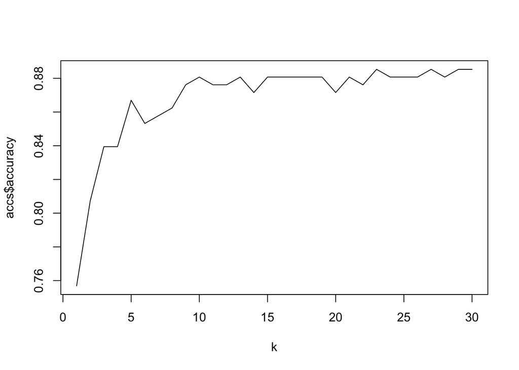

```r
accs = data.frame(accuracy = numeric(30), k = numeric(30))
for(i in 1:30)
{
  classifications = knn(train[,2:16],test[,2:16],train$Attrition, prob = TRUE, k = i)
  table(test$Attrition,classifications)
  CM = confusionMatrix(table(test$Attrition,classifications))
  accs$accuracy[i] = CM$overall[1]
  accs$k[i] = i
}
plot(accs$k,accs$accuracy, type = "l", xlab = "k")
```

```r
CV <- knn.cv(modeldf[,2:16],modeldf$Attrition,k=15)

confusionMatrix(table(CV,modeldf$Attrition))
```

```
## Confusion Matrix and Statistics
##
##
## CV    1   2
##   1 722 140
##   2   8   0
##
##                Accuracy : 0.8299
##                  95% CI : (0.8032, 0.8543)
##     No Information Rate : 0.8391
##     P-Value [Acc > NIR] : 0.7847
##
##                   Kappa : -0.0177
##
##  Mcnemar's Test P-Value : <2e-16
##
##             Sensitivity : 0.9890
##             Specificity : 0.0000
##          Pos Pred Value : 0.8376
##          Neg Pred Value : 0.0000
##              Prevalence : 0.8391
##          Detection Rate : 0.8299
##    Detection Prevalence : 0.9908
##       Balanced Accuracy : 0.4945
##
##        'Positive' Class : 1
##
```

Prepared the data so that we could predict Attrition

```r
#bring in data with no Attrition
No_attrition <-read.csv('//Users/muchigi.kimari@mckesson.com/Google Drive/Doing_data_science/Doing/CaseStudy2_2_2_2/CaseStudy2CompSet No Attrition.csv')

#selected the features from the data
No_attrition1<-No_attrition[,c(2,5,6,14,15,16,17,18,19,23,28,29,32,33,35)]
i <- sapply(No_attrition1,is.factor)

#Converted categorical data to Numerical numbers
No_attrition1[i] <- lapply(No_attrition1[i], as.numeric)

#Attrition resultss
PredictedAttrition <- knn(modeldf[,c(2:16)],No_attrition1,modeldf$Attrition, k=9)

#Put the results into a dataframe
PredictedAttrition<-data_frame(PredictedAttrition)
#changes the data type to factors because we want to convert the 1 and 0 to Yes and NO
PredictedAttrition$PredictedAttrition <- as.factor(PredictedAttrition$PredictedAttrition)

#changed the numeric values to No anf Yes
PredictedAttrition<-ifelse(PredictedAttrition$PredictedAttrition==1, "No", "Yes")

#convert to dataframe
PredictedAttrition<-data_frame(PredictedAttrition)

#merge the data No_attrition and the predicted results

AttritionResult<- merge(No_attrition,PredictedAttrition,by=0, all=TRUE)

AttritionResult<-AttritionResult[,-c(1)]


#save to CSV

write.csv(AttritionResult,'Case2PredictionsMuchigiKimariAttrition.csv')
```

Find features for predicting regression using stepwise selection

```r
regdf<-df

i <- sapply(regdf,is.factor)

regdf[i] <- lapply(regdf[i], as.numeric)


step.model <- train(MonthlyIncome ~., data = regdf,method ="lmStepAIC",trace = FALSE)


# this will give us the features
step.model[["finalModel"]][["coefficients"]]
```

```
##             (Intercept)          BusinessTravel              Department
##              -894.06824               185.63581              -731.31315
##        DistanceFromHome EnvironmentSatisfaction                JobLevel
##               -14.89965               -77.31175              3810.43917
##                 JobRole       TotalWorkingYears    YearsWithCurrManager
##               109.09810                59.74732               -53.63329
```

Fit a model with the stepwise features

```r
numMSPEs = 1000

MSPEHolderModel1 = numeric(numMSPEs)

for (i in 1:numMSPEs)
{
  TrainObs = sample(seq(1,dim(regdf)[1]),round(.75*dim(regdf)[1]),replace = FALSE)
  Train = regdf[TrainObs,]
  Test = regdf[-TrainObs,]
  Model1_fit = lm(MonthlyIncome ~  BusinessTravel + Department + DistanceFromHome + EnvironmentSatisfaction + JobLevel + JobRole + TotalWorkingYears + YearsWithCurrManager, data = Train)
  Model1_Preds = predict(Model1_fit, newdata = Test)

  #MSPE Model 1
  MSPE = mean((Test$MonthlyIncome - Model1_Preds)^2)
  MSPE
  MSPEHolderModel1[i] = MSPE



}
mean(MSPEHolderModel1)
```

```
## [1] 1816623
```

```r
summary(Model1_fit)
```

```
##
## Call:
## lm(formula = MonthlyIncome ~ BusinessTravel + Department + DistanceFromHome +
##     EnvironmentSatisfaction + JobLevel + JobRole + TotalWorkingYears +
##     YearsWithCurrManager, data = Train)
##
## Residuals:
##     Min      1Q  Median      3Q     Max
## -5304.1  -781.0   -31.4   689.6  4210.1
##
## Coefficients:
##                         Estimate Std. Error t value Pr(>|t|)
## (Intercept)             -878.853    359.123  -2.447 0.014663 *
## BusinessTravel           179.983     76.290   2.359 0.018613 *
## Department              -689.011    131.535  -5.238 2.20e-07 ***
## DistanceFromHome         -17.112      6.183  -2.768 0.005809 **
## EnvironmentSatisfaction -101.295     46.458  -2.180 0.029592 *
## JobLevel                3853.133     76.248  50.535  < 2e-16 ***
## JobRole                   97.251     28.367   3.428 0.000646 ***
## TotalWorkingYears         60.305     11.566   5.214 2.49e-07 ***
## YearsWithCurrManager     -60.578     16.348  -3.705 0.000229 ***
## ---
## Signif. codes:  0 '***' 0.001 '**' 0.01 '*' 0.05 '.' 0.1 ' ' 1
##
## Residual standard error: 1299 on 643 degrees of freedom
## Multiple R-squared:  0.9216, Adjusted R-squared:  0.9206
## F-statistic: 944.8 on 8 and 643 DF,  p-value: < 2.2e-16
```

Predict the Monthly income from the data in No Salary document

```r
#read Data
No_salary <-readxl::read_xlsx("/Users/muchigi.kimari@mckesson.com/Google Drive/Doing_data_science/Doing/case study/CaseStudy2CompSet No Salary.xlsx")

#convert the data to factors because the are in character type
No_salary$BusinessTravel <- as.factor(No_salary$BusinessTravel)
No_salary$Department <- as.factor(No_salary$Department)
No_salary$MaritalStatus <- as.factor(No_salary$MaritalStatus)
No_salary$JobRole <- as.factor(No_salary$JobRole)

#prepare the data
No_salary1 <-No_salary[,c(4,6,7,12,19,16,17,29,35)]
i <- sapply(No_salary1,is.object)

No_salary1[i] <- lapply(No_salary1[i], as.numeric)

str(No_salary1)
```

```
## Classes 'tbl_df', 'tbl' and 'data.frame':    300 obs. of  9 variables:
##  $ BusinessTravel         : num  2 3 3 1 3 3 1 2 2 3 ...
##  $ Department             : num  3 2 3 2 2 3 3 2 2 2 ...
##  $ DistanceFromHome       : num  2 13 13 9 19 5 22 10 23 11 ...
##  $ EnvironmentSatisfaction: num  1 2 1 1 4 4 3 1 1 4 ...
##  $ MaritalStatus          : num  2 3 3 2 1 2 2 3 1 3 ...
##  $ JobLevel               : num  2 1 4 1 1 2 2 1 1 4 ...
##  $ JobRole                : num  8 7 8 3 3 9 8 3 7 5 ...
##  $ TotalWorkingYears      : num  7 5 24 5 7 19 8 2 10 29 ...
##  $ YearsWithCurrManager   : num  7 2 8 2 7 0 7 2 9 3 ...
```

```r
#predict the results
PredictedMonthlyIncome<-predict(Model1_fit,No_salary1)

#convert results to dataframe
MonthlyIncome<-data_frame(PredictedMonthlyIncome)

#Merge the data
regression_data <- merge(No_salary,MonthlyIncome,by=0, all=TRUE)

regression_data<-regression_data[,-c(1)]


#save to CSV
write.csv(regression_data,'Case2PredictionsMuchigiKimariSalary.csv')
```